# COMP 162 Project Write-up

Annahi Olvera

2025-02-25

## Introduction:

Link to dataset: https://www.kaggle.com/datasets/arsalanjamal002/student-sleep-patterns?resource=download

### Description of data set:

This data set presents sleep patterns of university students, allowing us to identify correlations between various lifestyle factors (e.g. sleep duration, sleep quality, etc). The dataset is synthetic, which means it’s artificially generated but retains statistical properties, such as following realistic distributions and relationships.

### Observations:

Each row (observation) represents an individual university student.

Each column (variable) represents a different aspect of the student’s demographics, sleep patterns, and lifestyle habits.

### Motivation

The motivation for studying this dataset is to see if certain aspects of student’s lifestyle and behavioral factors have any relation to sleep patterns.

### Summary Statistics

#### Classified Variables

*Note: Student_ID is identifier

Binary:

Nominal: Gender

Ordinal: University_year, Sleep_Quality

Discrete: Age, Physical_Activity, Caffeine_Intake

Continuous: Sleep_Duration, Study_Hours, Screen_Time, Weekday_Sleep_Start, Weekday_Sleep_End, Weekend_Sleep_Start, Weekend_Sleep_End

#### Load Data

```r
library(tidyverse)
sleep <- read_csv("student_sleep_patterns.csv")
```

#### Display Data

```r
str(sleep)
```

```
## spc_tbl_ [500 × 14] (S3: spec_tbl_df/tbl_df/tbl/data.frame)
##  $ Student_ID         : num [1:500] 1 2 3 4 5 6 7 8 9 10 ...
##  $ Age                : num [1:500] 24 21 22 24 20 25 22 22 24 19 ...
##  $ Gender             : chr [1:500] "Other" "Male" "Male" "Other" ...
##  $ University_Year    : chr [1:500] "2nd Year" "1st Year" "4th Year" "4th Year" ...
##  $ Sleep_Duration     : num [1:500] 7.7 6.3 5.1 6.3 4.7 4.9 6.5 6.1 8.6 5.8 ...
##  $ Study_Hours        : num [1:500] 7.9 6 6.7 8.6 2.7 12 11.7 7.8 2.4 8.2 ...
##  $ Screen_Time        : num [1:500] 3.4 1.9 3.9 2.8 2.7 3.2 3.4 3 1.4 2 ...
##  $ Caffeine_Intake    : num [1:500] 2 5 5 4 0 3 1 1 1 3 ...
##  $ Physical_Activity  : num [1:500] 37 74 53 55 85 96 99 108 86 44 ...
##  $ Sleep_Quality      : num [1:500] 10 2 5 9 3 9 6 4 7 8 ...
##  $ Weekday_Sleep_Start: num [1:500] 14.16 8.73 20 19.82 20.98 ...
##  $ Weekend_Sleep_Start: num [1:500] 4.05 7.1 20.47 4.08 6.12 ...
##  $ Weekday_Sleep_End  : num [1:500] 7.41 8.21 6.88 6.69 8.98 5.04 8.58 5.6 8.14 7.47 ...
##  $ Weekend_Sleep_End  : num [1:500] 7.06 10.21 10.92 9.42 9.01 ...
##  - attr(*, "spec")=
##   .. cols(
##   ..   Student_ID = col_double(),
##   ..   Age = col_double(),
##   ..   Gender = col_character(),
##   ..   University_Year = col_character(),
##   ..   Sleep_Duration = col_double(),
##   ..   Study_Hours = col_double(),
##   ..   Screen_Time = col_double(),
##   ..   Caffeine_Intake = col_double(),
##   ..   Physical_Activity = col_double(),
##   ..   Sleep_Quality = col_double(),
##   ..   Weekday_Sleep_Start = col_double(),
##   ..   Weekend_Sleep_Start = col_double(),
##   ..   Weekday_Sleep_End = col_double(),
##   ..   Weekend_Sleep_End = col_double()
##   .. )
##  - attr(*, "problems")=<externalptr>
```

#### Variable Summary

```r
summary(sleep)
```

```
##    Student_ID         Age           Gender          University_Year
##  Min.   :  1.0   Min.   :18.00   Length:500         Length:500
##  1st Qu.:125.8   1st Qu.:20.00   Class :character   Class :character
##  Median :250.5   Median :21.00   Mode  :character   Mode  :character
##  Mean   :250.5   Mean   :21.54
##  3rd Qu.:375.2   3rd Qu.:24.00
##  Max.   :500.0   Max.   :25.00
##  Sleep_Duration   Study_Hours      Screen_Time    Caffeine_Intake
##  Min.   :4.000   Min.   : 0.100   Min.   :1.000   Min.   :0.000
##  1st Qu.:5.100   1st Qu.: 2.900   1st Qu.:1.800   1st Qu.:1.000
##  Median :6.500   Median : 6.050   Median :2.600   Median :2.000
##  Mean   :6.472   Mean   : 5.982   Mean   :2.525   Mean   :2.462
##  3rd Qu.:7.800   3rd Qu.: 8.800   3rd Qu.:3.300   3rd Qu.:4.000
##  Max.   :9.000   Max.   :12.000   Max.   :4.000   Max.   :5.000
##  Physical_Activity Sleep_Quality    Weekday_Sleep_Start Weekend_Sleep_Start
##  Min.   :  0.00    Min.   : 1.000   Min.   : 1.080      Min.   : 2.050
##  1st Qu.: 32.75    1st Qu.: 3.000   1st Qu.: 6.088      1st Qu.: 7.298
##  Median : 62.50    Median : 5.000   Median :10.635      Median :12.690
##  Mean   : 62.34    Mean   : 5.362   Mean   :11.167      Mean   :12.376
##  3rd Qu.: 93.25    3rd Qu.: 8.000   3rd Qu.:16.152      3rd Qu.:17.328
##  Max.   :120.00    Max.   :10.000   Max.   :21.930      Max.   :22.000
##  Weekday_Sleep_End Weekend_Sleep_End
##  Min.   :5.000     Min.   : 7.020
##  1st Qu.:5.900     1st Qu.: 8.047
##  Median :6.885     Median : 9.005
##  Mean   :6.930     Mean   : 8.988
##  3rd Qu.:7.973     3rd Qu.: 9.925
##  Max.   :8.980     Max.   :10.990
```

#### Variable information

Student_ID: Unique identifier for each student (integer)

Age: Age of the student in years (integer)

Gender: Gender of the student (categorical: ‘Male’, ‘Female’, ‘Other’)

University_Year: The student’s current year of university (categorical: ‘1st Year’, ‘2nd Year’, ‘3rd Year’, ‘4th Year’)

Sleep_Duration: Total hours of sleep per night (float)

Study_Hours: Average number of hours spent studying per day (float)

Screen_Time: Average number of hours spent on screens (excluding studying) per day (float)

Caffeine_Intake: Average number of caffeinated beverages consumed per day (integer)

Physical_Activity: Average minutes spent on physical activity per day (integer)

Sleep_Quality: Subjective rating of sleep quality on a scale of 1 to 10 (1 being the worst, 10 being the best) (integer)

Weekday_Sleep_Start: Time the student typically goes to sleep on weekdays (float, in 24-hour format, e.g., 23.00 is 11 PM)

Weekend_Sleep_Start: Time the student typically goes to sleep on weekends (float, in 24-hour format)

Weekday_Sleep_End: Time the student typically wakes up on weekdays (float, in 24-hour format)

Weekend_Sleep_End: Time the student typically wakes up on weekends (float, in 24-hour format)

## Visualizations

### One plot showing the relationship between two quantitative variables

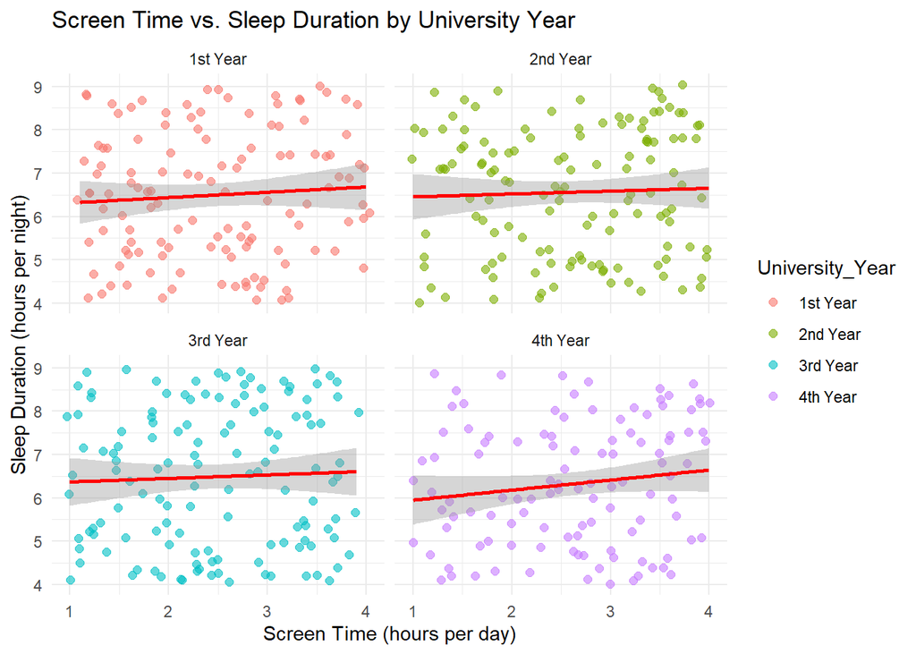

```r
# Screen Time vs Sleep Duration
ggplot(sleep, aes(x = Screen_Time, y = Sleep_Duration)) +
  geom_jitter(alpha = 0.6, size = 2, aes(color = University_Year)) +
  geom_smooth(method = "lm", se = TRUE, color = "red") +
  facet_wrap(~University_Year) +  # Separate plots by university year
  labs(title = "Screen Time vs. Sleep Duration by University Year",
       x = "Screen Time (hours per day)",
       y = "Sleep Duration (hours per night)") +
  theme_minimal()
```

### Interpretation

This plot shows the relationship between screen time and sleep duration, split by university year, and includes the following: Jittered points: helps visualize overlapping points by adjusting the position of points that share the same values for Screen_Time and Sleep_Duration

Coloring by University_Year: helps see if the relationship differs between first, second, third, and fourth year

Linear trend line: the red line represents the linear fit (using linear regression) to the data. It shows the general trend of how screen time influences sleep duration across the dataset

Faceting by University_Year: data is separated into four graphs based on University_Year. This allows us to compare the relationship between screen time and sleep duration that varies across different university years

### Before statistical analysis interpretation (for Screen Time vs Sleep Duration by University Year):

Looking at the plot, it seems that all four graphs have a slightly upwards trend line that suggests there is a positive relationship between screen time and sleep duration. Although the relationship is weak, this means that as screen time increases, sleep duration also tends to increase. Since the trend line is slightly upwards, the correlation may be weak and other factors might have a stronger influence on sleep duration. Faceting by University_Year also allows us to observe that within the 4th year, the trend line is slightly steeper, suggesting screen time has a stronger effect on sleep duration for 4th year students.The shaded region represents the confidence interval and lies between 6-7 hours. This can indicate that the model predicts sleep duration will be around 6-7 hours, regardless of increased screen time.

Interpreting this plot, one might expect higher screen time to lead to less sleep due to distractions or late-night use (counter intuitive), but possible scenarios to consider is: students may be studying more after screen time, which may result in staying up late and sleeping in more or may be using screen time to relax before bed, and leading to slightly more sleep

### One plot showing the relationship between a categorical and quantitative variable

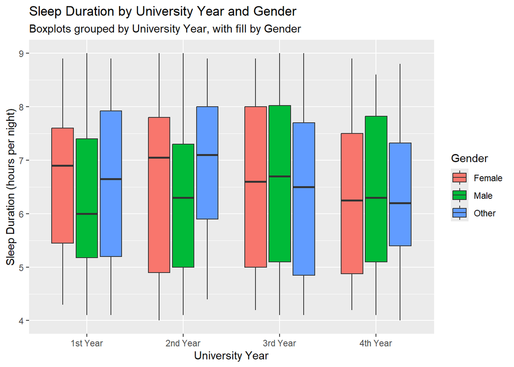

```r
# University_Year vs Sleep_Duration
ggplot(sleep, aes(x = University_Year,
                  y = Sleep_Duration,
                  fill = Gender)) +
  labs(title = "Sleep Duration by University Year and Gender",
       subtitle = "Boxplots grouped by University Year, with fill by Gender",
       x = "University Year",
       y = "Sleep Duration (hours per night)") +
  geom_boxplot()
```

### Interpretation This plot shows the distribution of sleep duration for each university year, colored differently for each gender and includes the following: X-axis (University Year): represents the university years

Y-axis (Sleep Duration): represents the number of hours of sleep

Filled by Gender: allowing for a visual distinction between different genders within each university year

### Before statistical analysis interpretation (Sleep Duration by University Year and Gender):

Considering 1st years: The box plot shows female students may generally sleep more than males and others by looking at their median sleep duration being higher. This can suggest that female students prioritize sleep or have different lifestyle habits that allow them to sleep more. Additionally, others seems to have more variability in sleep duration based on a wider interquartile range.

Considering 2nd years: The box plot shows other students sleep more than females and males by looking at their median sleep duration being slightly more higher than females and males. With a smaller interquartile range, others have less variability. This can suggest others students have a more consistent sleep duration. In contrast, females seem to have more variability in sleep duration based on a wider interquartile range.

Considering 3rd years: The box plot shows male students sleep slightly more than females and others by looking at their median being slightly higher than females and others. Variability seems to be roughly the same across all genders but students in the other group tend to sleep slightly less overall, suggested by the box being more towards the left.

Considering 4th years: The box plot shows the average sleep duration is very similar across all genders in the 4th year. Male students sleep longer on average compared to females and others by having a box more towards the right, while females sleeping less, and others having a more consistent sleep duration.

Overall: On average, females have a higher sleep duration for 1st years, others have a higher sleep duration for 2nd years, males have a higher sleep duration for 3rd years, and similar sleep duration but slightly higher for males for 4th years.

Sleep habits become more uniform across genders by the final year.

## Dataset manipulations

### One plot based on a dplyr manipulation

### Sleep subset of 1st Year University Students

```r
# Filtering 1st years
sleep1 <- sleep %>%
  filter(University_Year == "1st Year")
head(sleep1)
```

```
## # A tibble: 6 × 14
##   Student_ID   Age Gender University_Year Sleep_Duration Study_Hours Screen_Time
##        <dbl> <dbl> <chr>  <chr>                    <dbl>       <dbl>       <dbl>
## 1          2    21 Male   1st Year                   6.3         6           1.9
## 2          6    25 Other  1st Year                   4.9        12           3.2
## 3          9    24 Female 1st Year                   8.6         2.4         1.4
## 4         11    20 Female 1st Year                   6.9         0.9         3.8
## 5         19    25 Female 1st Year                   4.4         4.2         1.4
## 6         32    18 Female 1st Year                   4.3         7.1         3.2
## # ℹ 7 more variables: Caffeine_Intake <dbl>, Physical_Activity <dbl>,
## #   Sleep_Quality <dbl>, Weekday_Sleep_Start <dbl>, Weekend_Sleep_Start <dbl>,
## #   Weekday_Sleep_End <dbl>, Weekend_Sleep_End <dbl>
```

### Weekend vs Weekday Sleep Duration by 1st Year

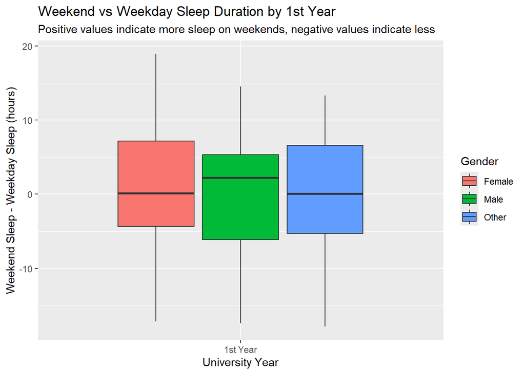

```r
# Calculate Weekend and Weekday Sleep Duration
sleep1 <- sleep1 %>%
  mutate(
    Weekday_Sleep_Duration = Weekday_Sleep_End - Weekday_Sleep_Start,
    Weekend_Sleep_Duration = Weekend_Sleep_End - Weekend_Sleep_Start
  )

# Calculate sleep duration difference
sleep1 <- sleep1 %>%
  mutate(Sleep_Duration_Difference = Weekend_Sleep_Duration - Weekday_Sleep_Duration)

# Box plot to show variation in sleep compensation across university years
ggplot(sleep1, aes(x = University_Year,
                  y = Sleep_Duration_Difference,
                  fill = Gender)) +
  geom_boxplot() +
  labs(title = "Weekend vs Weekday Sleep Duration by 1st Year",
       subtitle = "Positive values indicate more sleep on weekends, negative values indicate less",
       x = "University Year",
       y = "Weekend Sleep - Weekday Sleep (hours)")
```

### Interpretion This plot shows plot shows how first-year university students adjust their sleep on weekends compared to weekdays, with a breakdown by gender and includes the following: X-axis: represents university year (but only includes 1st year)

Y-axis: represents the difference in sleep duration between weekends and weekdays Positive values indicate students are catching up on sleep over the weekend. Negative values suggest students sleep less on weekends.

Fill by Gender: allows us to compare male, female, and other gender groups sleep patterns

Weekday_Sleep Duration (Weekday_Sleep_End - Weekday_Sleep_Start) and Weekend_Sleep_Duration (Weekend_Sleep_End - Weekend_Sleep_Start) variables were created to analyze how students’ sleep patterns differ between weekdays and weekends.

Sleep_Duration Difference (Weekend_Sleep_Duration - Weekday_Sleep_Duration) variable was created to understand how much sleep (or lack of sleep) students get on weekends relative to weekdays.

This plot can reveal insight on how students manage their sleep during the weekdays and weekends. By using data manipulation, we are able to explore and uncover hidden patterns to understand students’ sleep behavior.

### Before statistical analysis interpretation (Weekend vs Weekday Duration by 1st Year ):

On average, male students have the highest median (longer sleep duration during weekends) compared to females and others. Meanwhile, for both females and others, weekend and weekday sleep duration are similar for both groups, possibly indicating that there’s not much of a difference between amount of sleep students get on weekends compared to weekdays for these two groups.

## One correlation between two quantitive variables in your dataset

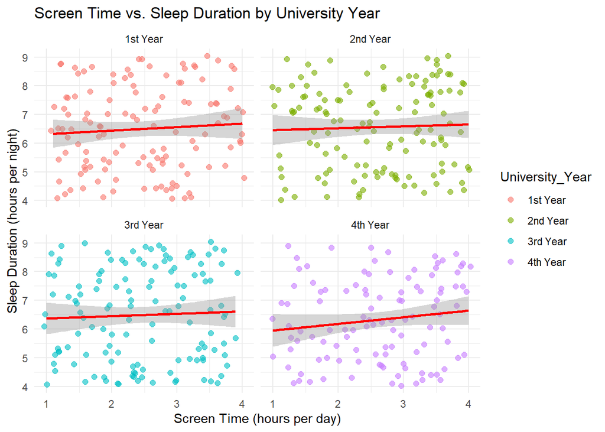

```r
# Screen Time vs Sleep Duration
ggplot(sleep, aes(x = Screen_Time, y = Sleep_Duration)) +
  geom_jitter(alpha = 0.6, size = 2, aes(color = University_Year)) +
  geom_smooth(method = "lm", se = TRUE, color = "red") +
  facet_wrap(~University_Year) +  # Separate plots by university year
  labs(title = "Screen Time vs. Sleep Duration by University Year",
       x = "Screen Time (hours per day)",
       y = "Sleep Duration (hours per night)") +
  theme_minimal()
```

## Correlation Test for each University Year

```r
# Correlation Test for each University Year
sleep %>%
  group_by(University_Year) %>%
  summarise(
    Pearson_Correlation = cor(Screen_Time, Sleep_Duration, method = "pearson"),
    Spearman_Correlation = cor(Screen_Time, Sleep_Duration, method = "spearman"),
    Pearson_p_value = cor.test(Screen_Time, Sleep_Duration, method = "pearson")$p.value,
    Spearman_p_value = cor.test(Screen_Time, Sleep_Duration, method = "spearman")$p.value
  )
```

```
## # A tibble: 4 × 5
##   University_Year Pearson_Correlation Spearman_Correlation Pearson_p_value
##   <chr>                         <dbl>                <dbl>           <dbl>
## 1 1st Year                     0.0715               0.0642           0.428
## 2 2nd Year                     0.0398               0.0601           0.651
## 3 3rd Year                     0.0429               0.0484           0.625
## 4 4th Year                     0.140                0.146            0.141
## # ℹ 1 more variable: Spearman_p_value <dbl>
```

## Interpretation

The correlation between Screen Time and Sleep Duration across all university years was not statistically significant at the 0.05 level. This suggests that there is no strong evidence of a meaningful relationship between these variables in this sample.

While the correlation coefficients are small, I was not able to find significant evidence of a relationship.

The correlation coefficients are small, ranging from 0.04 to 0.14, indicating weak positive relationships, but none of them reached statistical significance.

Based on the p-values shared, we can conclude that there is no statistically significant relationship between Screen Time and Sleep Duration across the university years when using p = 0.05.

## Correlation Test with all University Years

### Spearman Correlation

```r
# Calculate the Spearman correlation between Screen_Time and Sleep_Duration
cor.test(sleep$Screen_Time, sleep$Sleep_Duration, method = "spearman")
```

```
##
##  Spearman's rank correlation rho
##
## data:  sleep$Screen_Time and sleep$Sleep_Duration
## S = 19354976, p-value = 0.113
## alternative hypothesis: true rho is not equal to 0
## sample estimates:
##        rho
## 0.07095743
```

```r
# Calculate correlation coefficient (spearman)
cor(sleep$Screen_Time, sleep$Sleep_Duration, method = "spearman")
```

```
## [1] 0.07095743
```

## Interpretation

The correlation of 0.07096 suggests a very weak positive relationship between Screen Time and Sleep Duration across all university years combined.

The Spearman rank correlation between Screen Time and Sleep Duration across all university years is weak (ρ = 0.07096), and the relationship is not statistically significant (p = 0.113). This suggests that there is no meaningful monotonic relationship between Screen Time and Sleep Duration when considering all university years together.

### Pearson Correlation

```r
# calculate the Pearson correlation between Screen_Time and Sleep_Duration
cor.test(sleep$Screen_Time, sleep$Sleep_Duration, method = "pearson")
```

```
##
##  Pearson's product-moment correlation
##
## data:  sleep$Screen_Time and sleep$Sleep_Duration
## t = 1.5195, df = 498, p-value = 0.1293
## alternative hypothesis: true correlation is not equal to 0
## 95 percent confidence interval:
##  -0.01987536  0.15470263
## sample estimates:
##        cor
## 0.06793363
```

```r
# Calculate correlation coefficient (pearson)
cor(sleep$Screen_Time, sleep$Sleep_Duration, method = "pearson")
```

```
## [1] 0.06793363
```

## Interpretation

The correlation of 0.0679 suggests a very weak positive relationship between Screen Time and Sleep Duration across all university years combined.

The Pearson correlation between Screen Time and Sleep Duration was weak (r = 0.06793), and the result was not statistically significant (p = 0.1293). The 95% confidence interval for the correlation coefficient ranged from -0.0199 to 0.1547, indicating that the true correlation could be close to zero. Therefore, we conclude that there is no significant linear relationship between Screen Time and Sleep Duration when considering all university years together.

### Overall

Both the Pearson and Spearman tests suggest a very weak correlation between Screen Time and Sleep Duration, and neither of these correlations is statistically significant.

## One linear regression between two quantitative variables

```r
model <- lm(Sleep_Duration ~ Screen_Time, data = sleep)
summary(model)
```

```
##
## Call:
## lm(formula = Sleep_Duration ~ Screen_Time, data = sleep)
##
## Residuals:
##      Min       1Q   Median       3Q      Max
## -2.52819 -1.34287  0.08658  1.27147  2.63624
##
## Coefficients:
##             Estimate Std. Error t value Pr(>|t|)
## (Intercept)  6.17585    0.20613   29.96   <2e-16 ***
## Screen_Time  0.11744    0.07729    1.52    0.129
## ---
## Signif. codes:  0 '***' 0.001 '**' 0.01 '*' 0.05 '.' 0.1 ' ' 1
##
## Residual standard error: 1.484 on 498 degrees of freedom
## Multiple R-squared:  0.004615,   Adjusted R-squared:  0.002616
## F-statistic: 2.309 on 1 and 498 DF,  p-value: 0.1293
```

```r
# Intercept: 6.17585
# p-value: 0.1293
# slope regression line: 0.11744 (Screen_Time)
```

## Interpretation

The intercept is 6.17585, which means that when Screen Time is zero, the predicted Sleep Duration is about 6.18 hours.

The coefficient for Screen Time is 0.11744. This means that for every additional hour of Screen Time, Sleep Duration is expected to increase by about 0.117 hours on average

The p-value for Screen Time is 0.129, which is greater than 0.05, indicating that the relationship between Screen Time and Sleep Duration is not statistically significant. Therefore, there is insufficient evidence to support a meaningful linear relationship between Screen Time and Sleep Duration in this case.

The residual standard error is 1.484, which provides an estimate of the average distance that the observed values fall from the regression line.

### Overall

The linear regression analysis showed a weak positive correlation between Screen Time and Sleep Duration (β = 0.11744). However, the relationship was not statistically significant (p = 0.129), suggesting that Screen Time is not a strong predictor of Sleep Duration in this dataset.

## One t-test between a categorical and quantitative variable

```r
# Sleep Duration between 1st and 4th years
# Filter data for 1st Year and 4th Year students
sleep_1st_4th <- sleep %>%
  filter(University_Year == "1st Year" | University_Year == "4th Year")

# Perform independent t-test
t.test(Sleep_Duration ~ University_Year, data = sleep_1st_4th)
```

```
##
##  Welch Two Sample t-test
##
## data:  Sleep_Duration by University_Year
## t = 0.90202, df = 233.82, p-value = 0.368
## alternative hypothesis: true difference in means between group 1st Year and group 4th Year is not equal to 0
## 95 percent confidence interval:
##  -0.2007071  0.5396928
## sample estimates:
## mean in group 1st Year mean in group 4th Year
##               6.493600               6.324107
```

## Interpretation

p-value: 0.368

95% Confidence Interval: [-0.2007, 0.5397]

Mean Sleep Duration: 1st Year: 6.49 hours 4th Year: 6.32 hours Difference: 6.49 - 6.32 = 0.17 hours

### Overall

Since p = 0.368 (which is greater than 0.05), there is no statistically significant difference in sleep duration between 1st Year and 4th Year students.

The confidence interval includes zero, meaning the actual difference in means could be positive, negative, or zero.

The effect size (mean difference of 0.17 hours) is small, so even if significant, it wouldn’t be practically meaningful.

## Conclusion

### Corelation

Weak or No Significant Correlation Between Screen Time and Sleep Duration:

The correlation analysis (both Pearson and Spearman) showed a very weak positive relationship between screen time and sleep duration, but it was not statistically significant. The weak correlation suggests that other factors might play a larger role in influencing sleep duration.

### T-test

Sleep Duration is Fairly Consistent Across University Years:

The t-test comparing sleep duration between 1st-year and 4th-year students found no significant difference (p = 0.368). This suggests that sleep habits remain relatively stable across different university years.

### Linear Regression

Screen Time Does Not Strongly Predict Sleep Duration

Linear regression analysis showed that while an increase in screen time slightly increases sleep duration (β = 0.11744), this effect was not statistically significant (p = 0.129). This means screen time alone is not a strong predictor of sleep duration, contradicting the common assumption that more screen time leads to less sleep.

### Sleep Duration by University Years and Gender

Variability in Sleep Duration Across Genders:

Box plots of sleep duration by university year and gender indicated some differences, with: Females sleeping slightly more in 1st year Males sleeping slightly more in 3rd and 4th year Others showing more variability in certain years However, by the final year, sleep habits appear more uniform across genders.

### Weekend vs Weekday Sleep Duration by 1st Year

First-Year Students Compensate for Sleep on Weekends:

The box plot of weekend vs. weekday sleep for 1st-year students showed that males tend to sleep more on weekends compared to females and others.

## Conclusion

Sleep duration among university students remains relatively stable across years, with no strong relationship between screen time and sleep duration.

Gender-based differences exist but are not extreme, and weekend sleep compensation is observed mainly among male students.

Other lifestyle factors may be more influential in determining sleep duration.